# Original Work - Sleep Phenotypes Breakdown by Gender

# Reading the Data

We are interested in studying the various sleep phenotypes and their breakdowns in the different genders. We will be using data visualization strategies, specifically with overlaid histograms, to observe and analyze the data. Below are the subsequent plots. Overlaid histograms present the best possible visualization opportunity by presenting the frequency of a certain phenotype as well as effectively representing the gender differences for the data collected. Density plots were also created in order ot provide a more holistic visualization of the overall data distribution.

# Histograms

## Histogram Plot - Trouble Sleeping

Below is the histogram for the trouble sleeping variable. This variable looks at the frequency of trouble falling asleep for the participants of the study.

The question posed to the subjects was: How often do you have trouble falling asleep?

The recorded results were from 1 - 5.

– 1 - Never (0)

– 2 - Rarely (1x/month or less)

– 3 - Sometimes (2-4x/month)

– 4 - Often (5-15x/month)

– 5 - Almost Always (16 - 30x/month)

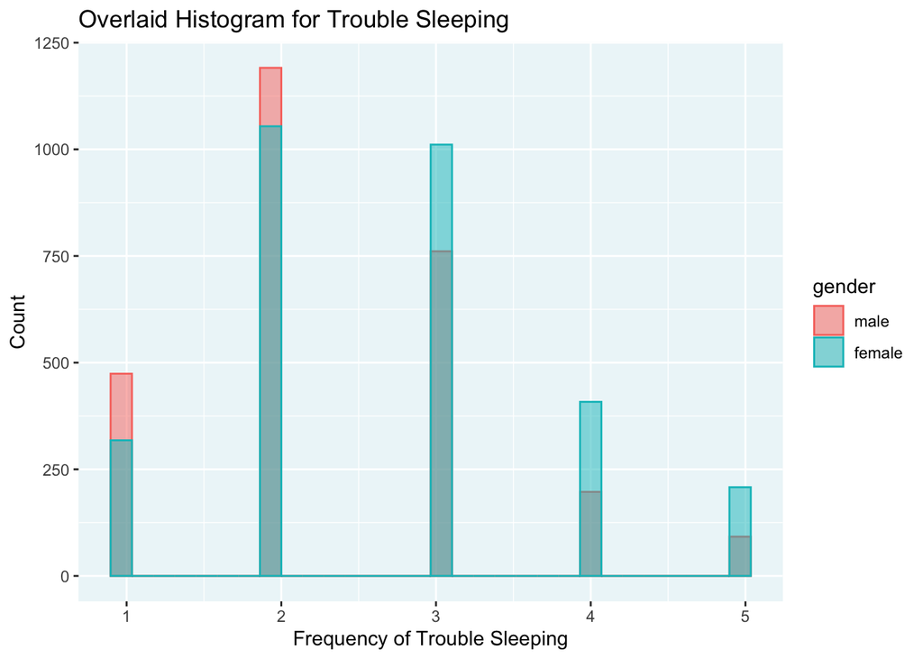

## Histogram Plot - Waking Early

Below is the histogram for the waking up early variable. This variable looks at the frequency of waking up early and not being able to fall back to sleep again.

The question posed to the subjects was: How often do you wake up too early in the morning and are unable to resume sleep?

The recorded results were from 1 - 5.

– 1 - Never (0)

– 2 - Rarely (1x/month or less)

– 3 - Sometimes (2-4x/month)

– 4 - Often (5-15x/month)

– 5 - Almost Always (16 - 30x/month)

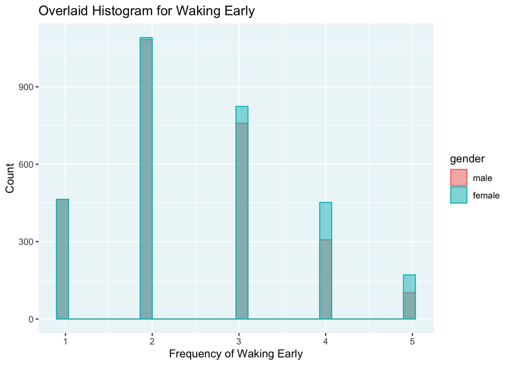

## Histogram Plot - Respiratory Disturbance Index

Below is the histogram for the Overall Respiratory Disturbance Index (RDI) at >=3% oxygen desaturation.

This value was calculated through the use of the following formula:

rdi3p = 60 * ( hrembp3 + hrop3 + hnrbp3 + hnrop3 + carbp3 + carop3 + canbp3 + canop3 + oarbp3 + oarop3 + oanbp3 + oanop3 ) / slpprdp

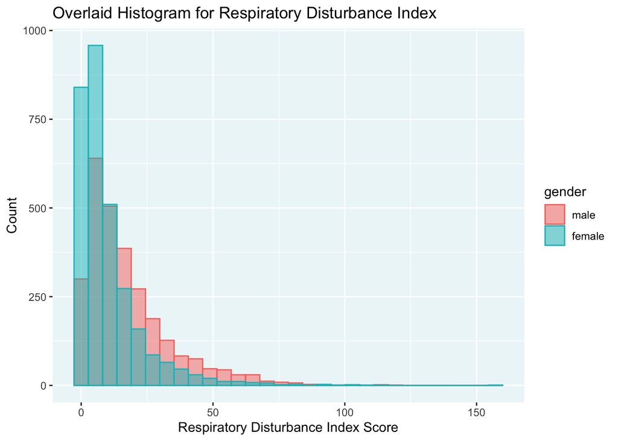

## Histogram Plot - Epworth Sleepiness Scale Score

Below is the histogram for the Epworth Sleepiness Scale score. This is an 8-question survey used to analyze the sleep patterns of subjects.

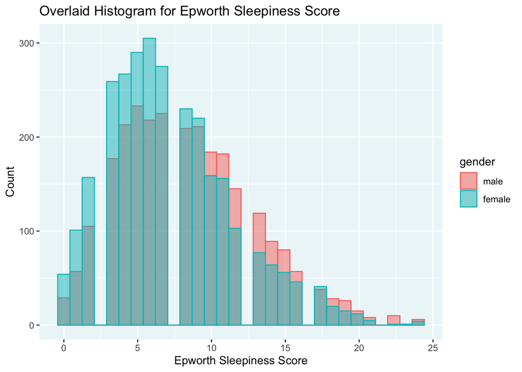

## Histogram Plot - Sleep Efficiency

Below is the histogram for the overall Sleep Efficiency values for subjects.Sleep efficiency is the percent of the time spent asleep while in bed.

This value was calculated through the use of the following formula. This was found by dividing the amount of time spent asleep by the total amount of time in bed.

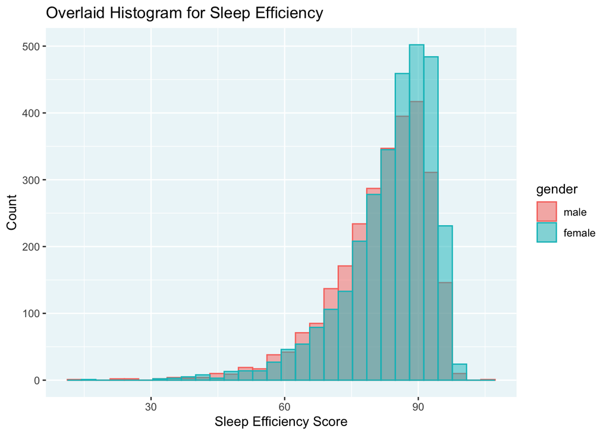

## Histogram Plot - Leg Cramps

Below is the histogram for the frequency of leg cramps/jerks waking up subjects.

The question posed to the subjects was: In the past year, how often, on average, have you been awakened with leg cramps or leg jerks?

The recorded results were from 1 - 5.

– 1 - Never (0)

– 2 - Rarely (1x/month or less)

– 3 - Sometimes (2-4x/month)

– 4 - Often (5-15x/month)

– 5 - Almost Always (16 - 30x/month)

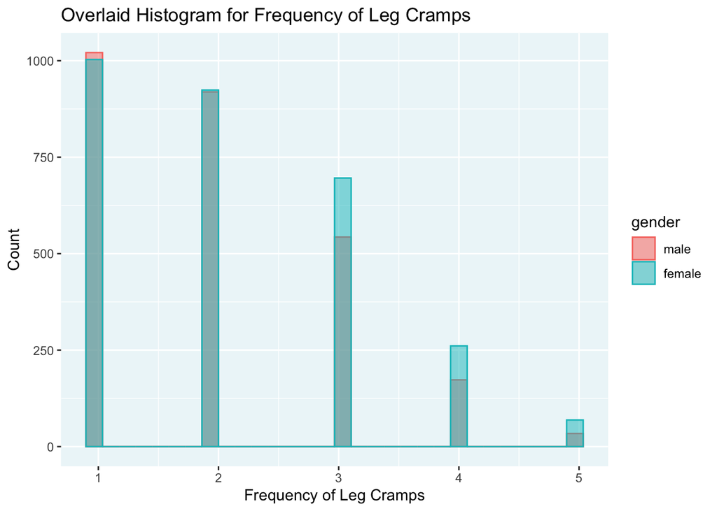

# Density Plots

## Density Plot - Trouble Sleeping

Below is the density plot for the trouble sleeping variable. This variable looks at the frequency of trouble falling asleep for the participants of the study.

The question posed to the subjects was: How often do you have trouble falling asleep?

The recorded results were from 1 - 5.

– 1 - Never (0)

– 2 - Rarely (1x/month or less)

– 3 - Sometimes (2-4x/month)

– 4 - Often (5-15x/month)

– 5 - Almost Always (16 - 30x/month)

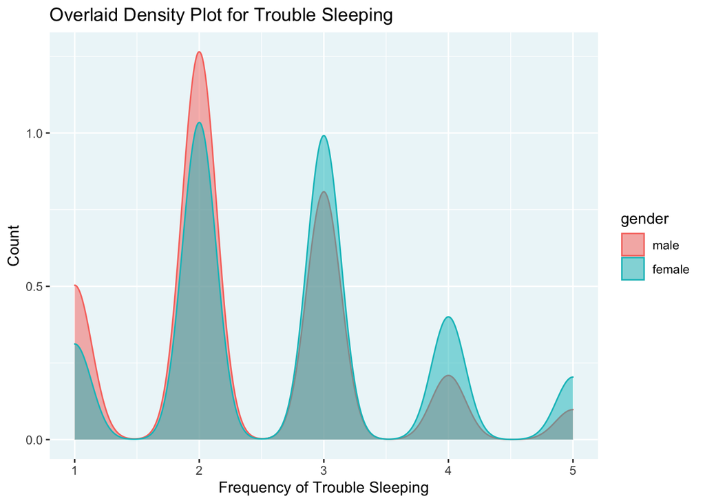

## Density Plot - Waking Early

Below is the density plot for the waking up early variable. This variable looks at the frequency of waking up early and not being able to fall back to sleep again.

The question posed to the subjects was: How often do you wake up too early in the morning and are unable to resume sleep?

The recorded results were from 1 - 5.

– 1 - Never (0)

– 2 - Rarely (1x/month or less)

– 3 - Sometimes (2-4x/month)

– 4 - Often (5-15x/month)

– 5 - Almost Always (16 - 30x/month)

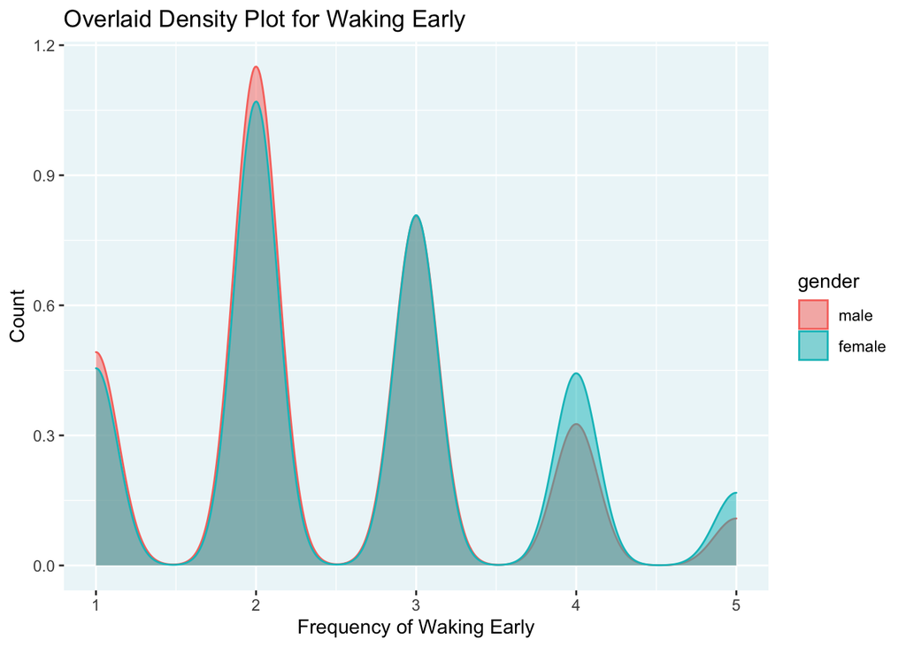

## Density Plot - Respiratory Disturbance Index

Below is the density plot for the Overall Respiratory Disturbance Index (RDI) at >=3% oxygen desaturation.

This value was calculated through the use of the following formula:

rdi3p = 60 * ( hrembp3 + hrop3 + hnrbp3 + hnrop3 + carbp3 + carop3 + canbp3 + canop3 + oarbp3 + oarop3 + oanbp3 + oanop3 ) / slpprdp

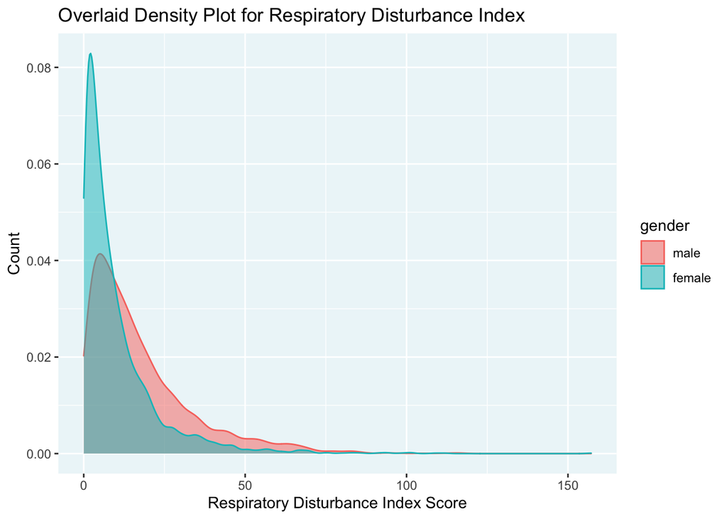

## Density Plot - Epworth Sleepiness Scale Score

Below is the density plot for the Epworth Sleepiness Scale score. This is an 8-question survey used to analyze the sleep patterns of subjects.

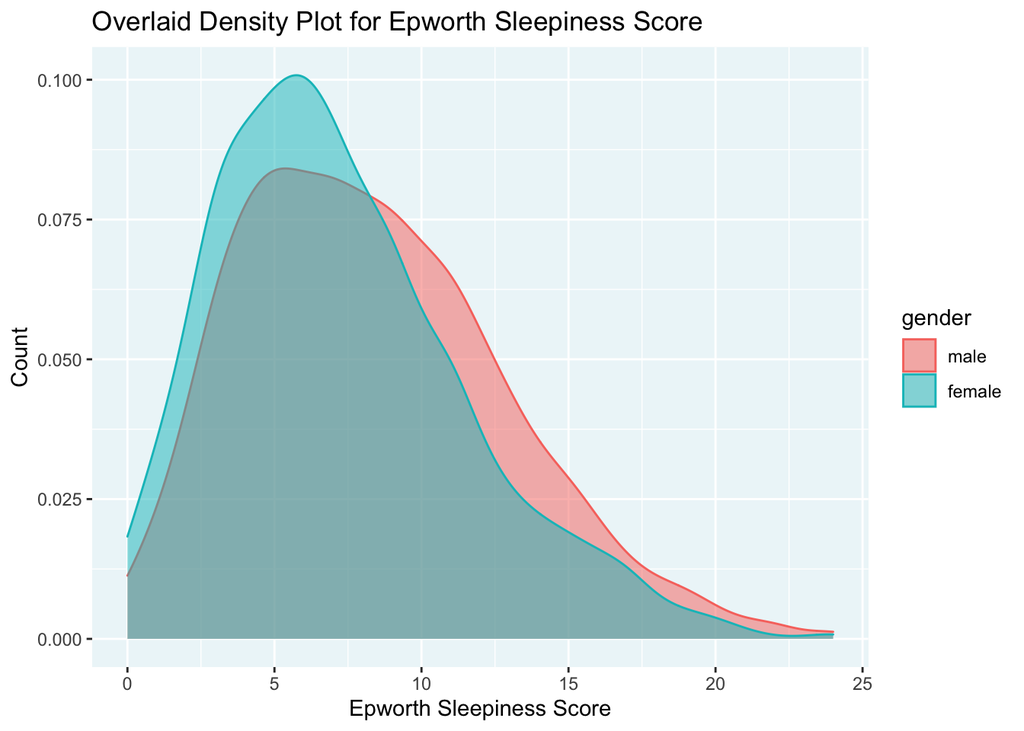

## Density Plot - Sleep Efficiency

Below is the density plot for the overall Sleep Efficiency values for subjects.Sleep efficiency is the percent of the time spent asleep while in bed.

This value was calculated through the use of the following formula of dividing the amount of time spent asleep by the total amount of time in bed.

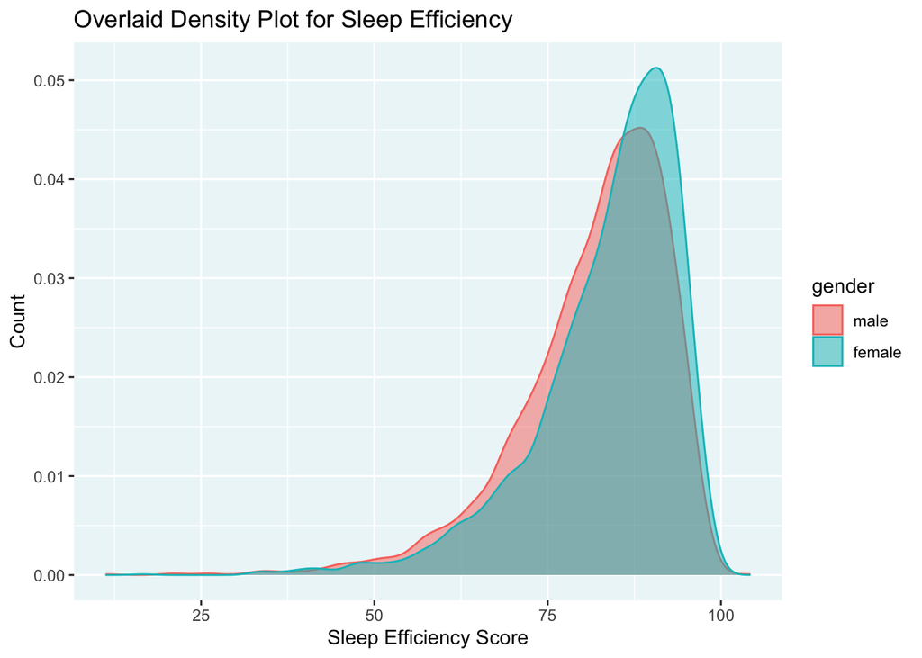

## Density Plot - Leg Cramps

Below is the density plot for the frequency of leg cramps/jerks waking up subjects.

The question posed to the subjects was: In the past year, how often, on average, have you been awakened with leg cramps or leg jerks?

The recorded results were from 1 - 5.

– 1 - Never (0)

– 2 - Rarely (1x/month or less)

– 3 - Sometimes (2-4x/month)

– 4 - Often (5-15x/month)

– 5 - Almost Always (16 - 30x/month)

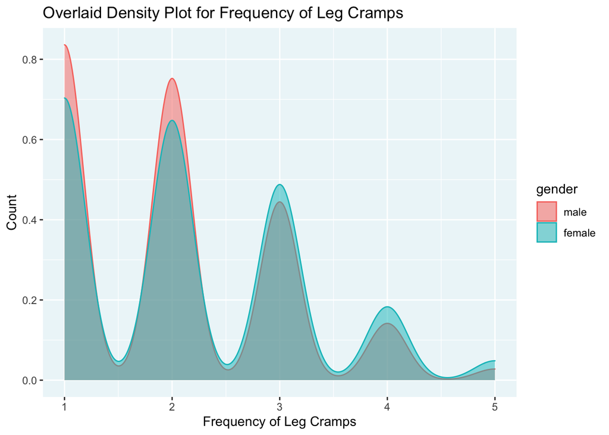